# Clustering

Sean Schilk

2025-9-18

## Question 2 : Read in data set called HW3data.csv. Call it acs. This data set has socioeconomic information for all 50 US states plus the District of Columbia. This information comes from the 2017 American Community Survey (ACS). This is a yearly survey done to help with the Census that is administered every 10 years

```r
setwd("~/STA419/REDO/3.Clustering")
acs <- read.csv("HW3data (1).csv")
  str(acs)
```

```
## 'data.frame':    51 obs. of  32 variables:
##  $ State           : chr  "Alabama" "Alaska" "Arizona" "Arkansas" ...
##  $ TotalPop        : int  4850771 738565 6809946 2977944 38982847 5436519 3594478 943732 672391 20278447 ...
##  $ Men             : num  0.485 0.523 0.497 0.491 0.497 ...
##  $ Women           : num  0.515 0.477 0.503 0.509 0.503 ...
##  $ VotingAgeCitizen: num  0.753 0.718 0.689 0.733 0.641 ...
##  $ MeanCommute     : num  24.7 19.2 25.3 21.7 28.9 ...
##  $ Employed        : num  0.424 0.479 0.434 0.429 0.462 ...
##  $ Hispanic_       : num  0.0409 0.068 0.3089 0.0716 0.3875 ...
##  $ White_          : num  0.659 0.615 0.556 0.73 0.379 ...
##  $ Black_          : num  0.2641 0.0306 0.0405 0.1535 0.0554 ...
##  $ Native_         : num  0.00466 0.13768 0.03915 0.0057 0.00353 ...
##  $ Asian_          : num  0.0128 0.0606 0.0304 0.0141 0.1392 ...
##  $ Pacific_        : num  0.0003 0.01191 0.00176 0.00234 0.00355 ...
##  $ Poverty_        : num  0.182 0.102 0.172 0.184 0.152 ...
```

[output cut: 18 more lines]

The data set has 51 observations and 32 variables. Each of the variables are numeric except for the first (`State`).

## (a) Load the tidyverse and cluster packages. Let’s start by splitting up the data set into the state names and the actual data for each state. Type: state <- acs$State and data <- select(acs, -State)

```r
library(tidyverse)

state <- acs$State

data <- select(acs, -State)
```

Here we break up the data set into the data values (quantitative variables) and the one categorical variable.

## (b) K-means randomly picks starting points. Because of this, the cluster “labels” can be different from one run to the next. In other words, two people can run the same code on the same data but get seemingly different cluster labels. But it’s the same number of observations in the different clusters! Because of this, we are going to “set the seed” of the random number generator. Type: set.seed(1). This will ensure we all get consistent results

#Run K-means with k = 2 on data using 20 different randomly chosen starting points. Store the output in an object called km.2. Using the table( ) function, how many states were put in each of the two clusters?

```r
set.seed(1)
km.2 <- kmeans(data, 2, nstart = 20)
  clusters <- as.character(km.2$cluster) # turns the integers into characters (for later)
  table(clusters)
```

```
## clusters
##  1  2
## 47  4
```

Running K-means with k = 2 clusters, we see that 47 states are put in one cluster and the remaining 4 are put in the other cluster.

## (c) Let’s look at which states were put in the cluster with the fewest number of observations (if cluster 2 doesn’t have fewer states, then you forgot the set.seed(1) part!). Type: clusters <- km.2$cluster and then km.out < − data.frame(state, clusters). Use the filter( ) function on km.out to see which states fell in this group. Why do you think these states got put in their own group?

```r
km.out <- data.frame(state, clusters)
  filter(km.out, clusters == "2")
```

| state | clusters |
| --- | --- |
| California | 2 |
| Florida | 2 |
| New York | 2 |
| Texas | 2 |

Here, cluster 2 has fewer observations (4 states). Those states are California, Florida, New York, and Texas. These are the four most populated states by a very significant margin.

## (d) Just like PCA, K-means can be very dependent on units of measurement! Instead of looking at raw values, let’s center and scale the values by their column mean and standard deviation, respectively. Type: data.sc <- scale(data). This will be our new data set!

```r
data.sc <- scale(data)
```

## (e) Run K-means with k = 2 on this new data set. Store the output in an object called km.2.sc. How many states were put in each of the two clusters?

```r
set.seed(1)
km.2.sc <- kmeans(data.sc, 2, nstart = 20)
clusters.2 <- as.character(km.2.sc$cluster)
  table(km.2.sc$cluster)
```

```
##
##  1  2
## 19 32
```

After scaling the variables, we see there are 19 states in one cluster and 32 in the other cluster.

## (f) Type: km.2.sc$centers[ , 1:3]. This gives us the mean of the observations that fall in each of the two clusters of the first three variables. Let’s verify that these are correct. Use the data.frame( ) function to combine the scaled data with the cluster labels from the previous part. Now, use the group by( ) and summarize( ) functions to get the mean of TotalPop, Men, and Women (the first three variables), grouped by their cluster labels.

```r
km.2.sc$centers[ , 1:3]
```

```
##     TotalPop        Men      Women
## 1 -0.5163008  0.8619043 -0.8619043
## 2  0.3065536 -0.5117557  0.5117557
```

```r
km.out.2 <- data.frame(data.sc, clusters.2)

km.out.2 %>%
  group_by(clusters.2) %>%
  summarize(avg.totPop = mean(TotalPop),
            avg.Men = mean(Men),
            avg.Wom = mean(Women))
```

| clusters.2 | avg.totPop | avg.Men | avg.Wom |
| --- | --- | --- | --- |
| 1 | -0.5163008 | 0.8619043 | -0.8619043 |
| 2 | 0.3065536 | -0.5117557 | 0.5117557 |

Here, we verify that the average of the observations put in both clusters for every variable (that we can get from the `centers` object) is correct. I just looked at the first three variables.

## (g) Repeat part (e) with k = 3, 4, . . . , 8. You do NOT need to repeat part (f)! What would you pick as the optimal value of k using elbow/scree plots? You must explain your reasoning!

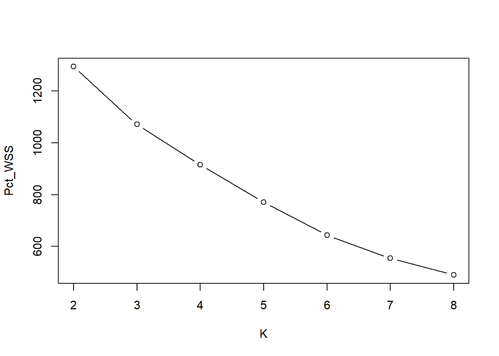

```r
set.seed(1)
  km.3.sc <- kmeans(data.sc, 3, nstart = 20)
set.seed(1)
  km.4.sc <- kmeans(data.sc, 4, nstart = 20)
set.seed(1)
  km.5.sc <- kmeans(data.sc, 5, nstart = 20)
set.seed(1)
  km.6.sc <- kmeans(data.sc, 6, nstart = 20)
set.seed(1)
  km.7.sc <- kmeans(data.sc, 7, nstart = 20)
set.seed(1)
  km.8.sc <- kmeans(data.sc, 8, nstart = 20)

plot(2:8, c(km.2.sc$tot.withinss,
            km.3.sc$tot.withinss,
            km.4.sc$tot.withinss,
            km.5.sc$tot.withinss,
            km.6.sc$tot.withinss,
            km.7.sc$tot.withinss,
            km.8.sc$tot.withinss), type = "b",
     xlab = "K", ylab = "Pct_WSS")
```

It isn’t very clear here which value of k we should be using. There appears to be a slight elbow at $k = 7$. So, let’s use that for now.

## (h) Use code similar to what you did in part (c) to see which states fall in each of the clusters. Comment on some of the similarities between the states within each cluster.

```r
set.seed(1)
clusters.sc.7 <- as.character(km.7.sc$cluster)
  table(clusters.sc.7)
```

```
## clusters.sc.7
##  1  2  3  4  5  6  7
##  1 13 15  6 10  5  1
```

```r
km.out.sc.7 <- data.frame(state, clusters.sc.7)

  filter(km.out.sc.7, clusters.sc.7 == "1")
```

| state | clusters.sc.7 |
| --- | --- |
| Hawaii | 1 |

```r
  filter(km.out.sc.7, clusters.sc.7 == "2")
```

| state | clusters.sc.7 |
| --- | --- |
| Colorado | 2 |
| Idaho | 2 |
| Iowa | 2 |
| Kansas | 2 |
| Maine | 2 |
| Minnesota | 2 |
| Nebraska | 2 |
| New Hampshire | 2 |
| Oregon | 2 |
| Utah | 2 |

[output cut: 3 more lines]

```r
  filter(km.out.sc.7, clusters.sc.7 == "3")
```

| state | clusters.sc.7 |
| --- | --- |
| Alabama | 3 |
| Arkansas | 3 |
| Georgia | 3 |
| Indiana | 3 |
| Kentucky | 3 |
| Louisiana | 3 |
| Michigan | 3 |
| Mississippi | 3 |
| Missouri | 3 |
| North Carolina | 3 |

[output cut: 5 more lines]

```r
  filter(km.out.sc.7, clusters.sc.7 == "4")
```

| state | clusters.sc.7 |
| --- | --- |
| Arizona | 4 |
| California | 4 |
| Florida | 4 |
| Nevada | 4 |
| New Mexico | 4 |
| Texas | 4 |

```r
  filter(km.out.sc.7, clusters.sc.7 == "5")
```

| state | clusters.sc.7 |
| --- | --- |
| Connecticut | 5 |
| Delaware | 5 |
| Illinois | 5 |
| Maryland | 5 |
| Massachusetts | 5 |
| New Jersey | 5 |
| New York | 5 |
| Pennsylvania | 5 |
| Rhode Island | 5 |
| Virginia | 5 |

```r
  filter(km.out.sc.7, clusters.sc.7 == "6")
```

| state | clusters.sc.7 |
| --- | --- |
| Alaska | 6 |
| Montana | 6 |
| North Dakota | 6 |
| South Dakota | 6 |
| Wyoming | 6 |

```r
  filter(km.out.sc.7, clusters.sc.7 == "7")
```

| state | clusters.sc.7 |
| --- | --- |
| District of Columbia | 7 |

## (i) We previously saw that we only had 51 observations and 32 variables. So, there is probably a LOT of redundant information here! In fact, some of the variables are perfectly correlated with one another. Therefore, let’s apply PCA first before clustering! This can act as a filter to remove noise. Run PCA on the ORIGINAL data set, but include the scale = TRUE argument. What proportion of the variation do the first six principal components explain?

```r
pca.sc <- prcomp(data, scale = TRUE)
  summary(pca.sc)
```

```
## Importance of components:
##                           PC1    PC2    PC3    PC4     PC5    PC6     PC7
## Standard deviation     2.7305 2.6108 2.2165 1.8331 1.39835 1.0981 1.02592
## Proportion of Variance 0.2405 0.2199 0.1585 0.1084 0.06308 0.0389 0.03395
## Cumulative Proportion  0.2405 0.4604 0.6189 0.7273 0.79034 0.8292 0.86319
##                            PC8     PC9    PC10    PC11    PC12    PC13    PC14
## Standard deviation     0.95189 0.83542 0.71417 0.64627 0.62422 0.59567 0.50603
## Proportion of Variance 0.02923 0.02251 0.01645 0.01347 0.01257 0.01145 0.00826
## Cumulative Proportion  0.89242 0.91493 0.93139 0.94486 0.95743 0.96887 0.97713
##                           PC15   PC16    PC17    PC18    PC19    PC20    PC21
## Standard deviation     0.41380 0.3431 0.32286 0.31120 0.25988 0.21717 0.18538
## Proportion of Variance 0.00552 0.0038 0.00336 0.00312 0.00218 0.00152 0.00111
## Cumulative Proportion  0.98266 0.9865 0.98982 0.99294 0.99512 0.99664 0.99775
##                           PC22   PC23    PC24    PC25    PC26    PC27      PC28
## Standard deviation     0.16042 0.1369 0.10672 0.08802 0.07514 0.02153 0.0003769
## Proportion of Variance 0.00083 0.0006 0.00037 0.00025 0.00018 0.00001 0.0000000
## Cumulative Proportion  0.99858 0.9992 0.99955 0.99980 0.99999 1.00000 1.0000000
##                             PC29      PC30      PC31
## Standard deviation     0.0002105 0.0001032 5.562e-15
## Proportion of Variance 0.0000000 0.0000000 0.000e+00
## Cumulative Proportion  1.0000000 1.0000000 1.000e+00
```

The first 6 PCs explain about 82.92% of the original variation in the data set. Which is pretty good considering we started with 31 (32 minus `State`) variables.

## (j) Get the rotated observations of the first six PCs as your new data set. Store this in a new object.

```r
new.coords <- pca.sc$x[, 1:6]
  d.pca <- dist(new.coords)
```

Here, we get the first six dimensions of the rotated observations and compute the Euclidean distances between the 51 observations in this new coordinate system.

## (k) Run K-means with k = 2, . . . , 8 on this new data set (from the previous part). Which value of k would you choose here?

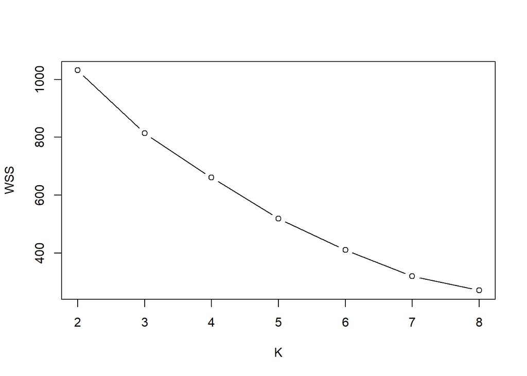

```r
set.seed(1)
km.pca.2 <- kmeans(new.coords, 2, nstart = 20)
set.seed(1)
km.pca.3 <- kmeans(new.coords, 3, nstart = 20)
set.seed(1)
km.pca.4 <- kmeans(new.coords, 4, nstart = 20)
set.seed(1)
km.pca.5 <- kmeans(new.coords, 5, nstart = 20)
set.seed(1)
km.pca.6 <- kmeans(new.coords, 6, nstart = 20)
set.seed(1)
km.pca.7 <- kmeans(new.coords, 7, nstart = 20)
set.seed(1)
km.pca.8 <- kmeans(new.coords, 8, nstart = 20)

plot(2:8, c(km.pca.2$tot.withinss,
            km.pca.3$tot.withinss,
            km.pca.4$tot.withinss,
            km.pca.5$tot.withinss,
            km.pca.6$tot.withinss,
            km.pca.7$tot.withinss,
            km.pca.8$tot.withinss), type = "b",
     xlab = "K", ylab = "WSS")
```

Again, let’s choose $k = 7$.

## (l) Use code similar to what you did (h) to see which states fall in each of the clusters. Comment on the states in these clusters relative to what you saw in part (h).

```r
clusters.pca.7 <- as.character(km.pca.7$cluster)
  table(clusters.pca.7)
```

```
## clusters.pca.7
##  1  2  3  4  5  6  7
## 10  1 13  1  5  6 15
```

```r
km.out.pca.7 <- data.frame(state, clusters.pca.7)
  filter(km.out.pca.7, clusters.pca.7 == "1")
```

| state | clusters.pca.7 |
| --- | --- |
| Connecticut | 1 |
| Delaware | 1 |
| Illinois | 1 |
| Maryland | 1 |
| Massachusetts | 1 |
| New Jersey | 1 |
| New York | 1 |
| Pennsylvania | 1 |
| Rhode Island | 1 |
| Virginia | 1 |

```r
  filter(km.out.pca.7, clusters.pca.7 == "2")
```

| state | clusters.pca.7 |
| --- | --- |
| District of Columbia | 2 |

```r
  filter(km.out.pca.7, clusters.pca.7 == "3")
```

| state | clusters.pca.7 |
| --- | --- |
| Colorado | 3 |
| Idaho | 3 |
| Iowa | 3 |
| Kansas | 3 |
| Maine | 3 |
| Minnesota | 3 |
| Nebraska | 3 |
| New Hampshire | 3 |
| Oregon | 3 |
| Utah | 3 |

[output cut: 3 more lines]

```r
  filter(km.out.pca.7, clusters.pca.7 == "4")
```

| state | clusters.pca.7 |
| --- | --- |
| Hawaii | 4 |

```r
  filter(km.out.pca.7, clusters.pca.7 == "5")
```

| state | clusters.pca.7 |
| --- | --- |
| Alaska | 5 |
| Montana | 5 |
| North Dakota | 5 |
| South Dakota | 5 |
| Wyoming | 5 |

```r
  filter(km.out.pca.7, clusters.pca.7 == "6")
```

| state | clusters.pca.7 |
| --- | --- |
| Arizona | 6 |
| California | 6 |
| Florida | 6 |
| Nevada | 6 |
| New Mexico | 6 |
| Texas | 6 |

```r
  filter(km.out.pca.7, clusters.pca.7 == "7")
```

| state | clusters.pca.7 |
| --- | --- |
| Alabama | 7 |
| Arkansas | 7 |
| Georgia | 7 |
| Indiana | 7 |
| Kentucky | 7 |
| Louisiana | 7 |
| Michigan | 7 |
| Mississippi | 7 |
| Missouri | 7 |
| North Carolina | 7 |

[output cut: 5 more lines]

The cluster assignments look to be identical to what we previously got! In general, this won’t always be the case. Especially, if we have reason to believe that there might be some *measurement* error within our data set.

## (m) Make a scatterplot with PC1 along the x-axis, PC2 along the y-axis, and color the points by the clusters you get from your optimal value of k.

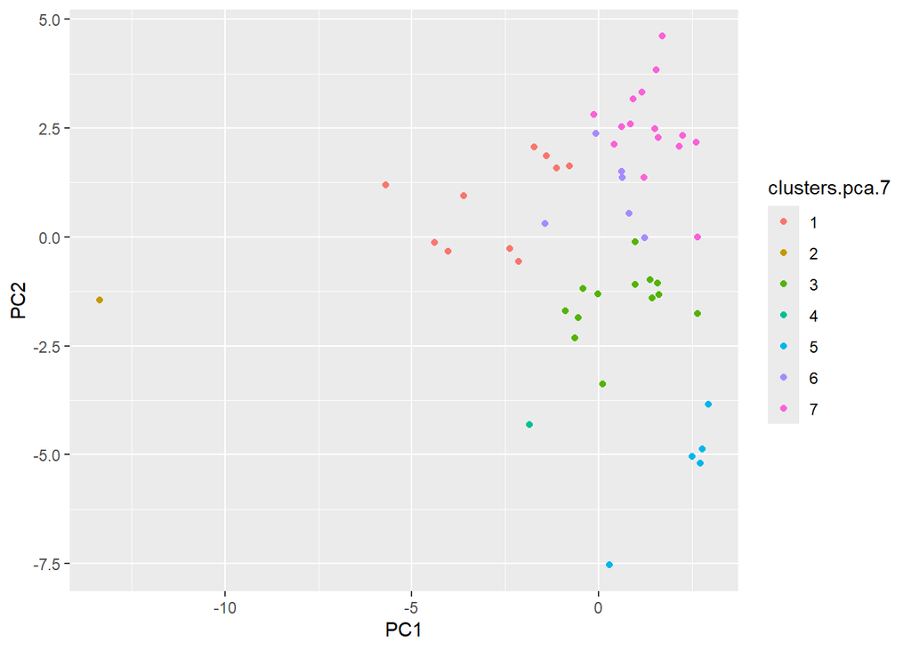

```r
pca.data.clus <- data.frame(new.coords, clusters.pca.7)

ggplot(pca.data.clus, aes(x = PC1, y = PC2, color = clusters.pca.7)) +
  geom_point( )
```

You can almost see the regionality of the states within the United States.